# 5-3. 데이터 분석 2차 - 모델링 및 평가

PCA결과를 바탕으로, 1차분석에서와 마찬가지로 매치별, 팀별 챔피언을 각 주성분의 값으로 대체한 후 모델에 학습 시킬 계획

아래 코드는 1차분석의 모델에 들어갈 x값의 전처리 과정과 유사하며, 자세한 설명은 생략

```python
import pandas as pd
import numpy as np
import matplotlib.pyplot as plt
import seaborn as sns
# 경고메세지 무시
import warnings
warnings.filterwarnings('ignore')
```

```python
# # 모든 행 출력
# pd.set_option('display.max_rows',None)
```

```python
# 팀별, 포지션별 df 로드
import pickle

with open("df_byTeam.pickle","rb") as fr:
    df_byTeam = pickle.load(fr)
df_byTeam.head()
```

| matchId | teamPosition win | BOTTOM | JUNGLE | MIDDLE | TOP | UTILITY |
| --- | --- | --- | --- | --- | --- | --- |
| KR_5944529373 | False | Tristana | Viego | Katarina | Trundle | Nautilus |
|  | True | Zeri | Graves | Sett | Gwen | Zilean |
| KR_5944532797 | False | Lucian | MonkeyKing | Ahri | Garen | Zilean |
|  | True | Jinx | Evelynn | Vladimir | Olaf | Seraphine |
| KR_5944532993 | False | MissFortune | Kindred | Leblanc | Malphite | Nautilus |

```python
df_byTeam.isnull().sum() # 결측치 확인
```

```
teamPosition
BOTTOM     0
JUNGLE     0
MIDDLE     0
TOP        0
UTILITY    0
dtype: int64
```

```python
df_byTeam.columns # 컬럼명 확인
```

```
Index(['BOTTOM', 'JUNGLE', 'MIDDLE', 'TOP', 'UTILITY'], dtype='object', name='teamPosition')
```

```python
with open("label_top2.pickle","rb") as fr:
    label_top = pickle.load(fr)
with open("label_jgl2.pickle","rb") as fr:
    label_jgl = pickle.load(fr)
with open("label_mid2.pickle","rb") as fr:
    label_mid = pickle.load(fr)
with open("label_bot2.pickle","rb") as fr:
    label_bot = pickle.load(fr)
with open("label_sup2.pickle","rb") as fr:
    label_sup = pickle.load(fr)
```

```python
e = label_top.reset_index()
label_top = e.rename(columns={'championName':'TOP'})
```

```python
e = label_jgl.reset_index()
label_jgl = e.rename(columns={'championName':'JUNGLE'})
```

```python
e = label_mid.reset_index()
label_mid = e.rename(columns={'championName':'MIDDLE'})
```

```python
e = label_bot.reset_index()
label_bot = e.rename(columns={'championName':'BOTTOM'})
```

```python
e = label_sup.reset_index()
label_sup = e.rename(columns={'championName':'UTILITY'})
```

```python
# 챔피언 네임에 pca결과 조인
labeledData = pd.merge(left=df_byTeam, right=label_top, how='left', on='TOP')
labeledData = pd.merge(left=labeledData, right=label_jgl, how='left', on='JUNGLE')
labeledData = pd.merge(left=labeledData, right=label_mid, how='left', on='MIDDLE')
labeledData = pd.merge(left=labeledData, right=label_bot, how='left', on='BOTTOM')
labeledData = pd.merge(left=labeledData, right=label_sup, how='left', on='UTILITY')
labeledData.head(10)
```

|  | BOTTOM | JUNGLE | MIDDLE | TOP | UTILITY | top_pc1 | top_pc2 | top_pc3 | top_pc4 | jgl_pc1 | ... | mid_pc3 | mid_pc4 | bot_pc1 | bot_pc2 | bot_pc3 | sup_pc1 | sup_pc2 | sup_pc3 | sup_pc4 | sup_pc5 |
| --- | --- | --- | --- | --- | --- | --- | --- | --- | --- | --- | --- | --- | --- | --- | --- | --- | --- | --- | --- | --- | --- |
| 0 | Tristana | Viego | Katarina | Trundle | Nautilus | 0.270250 | -0.914586 | -0.267005 | 0.119163 | 0.084020 | ... | 0.063497 | 1.201486 | -0.006609 | -0.513175 | -0.503054 | 0.398597 | -1.548296 | -0.647546 | -0.398336 | 0.698654 |
| 1 | Zeri | Graves | Sett | Gwen | Zilean | 0.279927 | -0.314131 | 0.705320 | -1.301689 | 0.065142 | ... | -0.585552 | -0.046424 | 0.059728 | 0.342432 | 0.836099 | -0.877707 | 0.274677 | 0.342761 | -0.057358 | -0.145070 |
| 2 | Lucian | MonkeyKing | Ahri | Garen | Zilean | 0.687933 | -0.746682 | -0.265716 | 0.627154 | -0.161862 | ... | 0.170739 | 0.062447 | -0.076940 | -0.123363 | -0.378755 | -0.877707 | 0.274677 | 0.342761 | -0.057358 | -0.145070 |
| 3 | Jinx | Evelynn | Vladimir | Olaf | Seraphine | 0.806792 | -1.272499 | -0.670444 | 0.052987 | -0.342787 | ... | 0.161387 | 0.262361 | -0.145374 | -0.221360 | -0.157697 | -0.595760 | -0.083321 | 0.984281 | -0.170991 | 0.043125 |
| 4 | MissFortune | Kindred | Leblanc | Malphite | Nautilus | -1.021076 | 1.506393 | 0.432076 | 0.563677 | 0.178768 | ... | 0.083833 | 0.500766 | 0.015991 | -0.247132 | -0.385745 | 0.398597 | -1.548296 | -0.647546 | -0.398336 | 0.698654 |
| 5 | Kaisa | Viego | Karma | Camille | Leona | 0.392586 | -0.676978 | -0.718021 | 0.225269 | 0.084020 | ... | -0.581297 | -0.610630 | -0.008943 | -0.258798 | -0.225118 | 0.045212 | -1.484890 | -0.547548 | -0.066513 | 0.213321 |
| 6 | Lucian | Sejuani | Katarina | Kassadin | Pyke | -0.494083 | 1.049819 | 1.121795 | -0.348041 | -0.360224 | ... | 0.063497 | 1.201486 | -0.076940 | -0.123363 | -0.378755 | 0.835076 | 0.431169 | -1.192572 | 2.020001 | -0.719289 |
| 7 | Kaisa | MonkeyKing | Lissandra | Swain | Nautilus | -0.325288 | 2.183136 | 1.215249 | 0.258818 | -0.161862 | ... | -0.407290 | -0.729024 | -0.008943 | -0.258798 | -0.225118 | 0.398597 | -1.548296 | -0.647546 | -0.398336 | 0.698654 |
| 8 | Twitch | Talon | Yasuo | Riven | Morgana | -0.025104 | -0.381817 | -0.608958 | 0.698015 | 0.523678 | ... | 0.045712 | -0.735884 | 0.304290 | -0.098765 | -0.768793 | 0.352373 | 0.171423 | 0.093084 | -0.889453 | 0.266064 |
| 9 | Draven | Poppy | Zoe | Rumble | Blitzcrank | -0.788737 | 1.010234 | 1.310052 | -1.059166 | -0.337911 | ... | 0.107694 | 0.284848 | 0.271102 | 0.088793 | -0.597266 | 0.158505 | -0.961071 | -0.617790 | -0.159405 | 0.165534 |

10 rows × 26 columns

```python
#결측치 확인
labeledData.isnull().sum()
```

```
BOTTOM     0
JUNGLE     0
MIDDLE     0
TOP        0
UTILITY    0
top_pc1    0
top_pc2    0
top_pc3    0
top_pc4    0
jgl_pc1    0
jgl_pc2    0
jgl_pc3    0
jgl_pc4    0
jgl_pc5    0
mid_pc1    0
mid_pc2    0
mid_pc3    0
mid_pc4    0
bot_pc1    0
bot_pc2    0
bot_pc3    0
sup_pc1    0
sup_pc2    0
sup_pc3    0
sup_pc4    0
sup_pc5    0
dtype: int64
```

```python
labeledData = labeledData.drop(['BOTTOM','JUNGLE','MIDDLE','TOP','UTILITY'],axis=1)
```

```python
labeledData.head(10)
```

|  | top_pc1 | top_pc2 | top_pc3 | top_pc4 | jgl_pc1 | jgl_pc2 | jgl_pc3 | jgl_pc4 | jgl_pc5 | mid_pc1 | ... | mid_pc3 | mid_pc4 | bot_pc1 | bot_pc2 | bot_pc3 | sup_pc1 | sup_pc2 | sup_pc3 | sup_pc4 | sup_pc5 |
| --- | --- | --- | --- | --- | --- | --- | --- | --- | --- | --- | --- | --- | --- | --- | --- | --- | --- | --- | --- | --- | --- |
| 0 | 0.270250 | -0.914586 | -0.267005 | 0.119163 | 0.084020 | -0.118592 | -0.628261 | -0.217910 | -0.197148 | -0.232805 | ... | 0.063497 | 1.201486 | -0.006609 | -0.513175 | -0.503054 | 0.398597 | -1.548296 | -0.647546 | -0.398336 | 0.698654 |
| 1 | 0.279927 | -0.314131 | 0.705320 | -1.301689 | 0.065142 | -0.726905 | -1.034056 | 0.076725 | -0.099828 | 1.314067 | ... | -0.585552 | -0.046424 | 0.059728 | 0.342432 | 0.836099 | -0.877707 | 0.274677 | 0.342761 | -0.057358 | -0.145070 |
| 2 | 0.687933 | -0.746682 | -0.265716 | 0.627154 | -0.161862 | 0.007579 | -0.560032 | -0.469986 | 0.097852 | -0.305748 | ... | 0.170739 | 0.062447 | -0.076940 | -0.123363 | -0.378755 | -0.877707 | 0.274677 | 0.342761 | -0.057358 | -0.145070 |
| 3 | 0.806792 | -1.272499 | -0.670444 | 0.052987 | -0.342787 | -0.097301 | 1.944184 | 1.275426 | -0.002226 | 0.091925 | ... | 0.161387 | 0.262361 | -0.145374 | -0.221360 | -0.157697 | -0.595760 | -0.083321 | 0.984281 | -0.170991 | 0.043125 |
| 4 | -1.021076 | 1.506393 | 0.432076 | 0.563677 | 0.178768 | -0.587934 | -0.738529 | 0.866534 | -0.574271 | -0.762267 | ... | 0.083833 | 0.500766 | 0.015991 | -0.247132 | -0.385745 | 0.398597 | -1.548296 | -0.647546 | -0.398336 | 0.698654 |
| 5 | 0.392586 | -0.676978 | -0.718021 | 0.225269 | 0.084020 | -0.118592 | -0.628261 | -0.217910 | -0.197148 | -0.997925 | ... | -0.581297 | -0.610630 | -0.008943 | -0.258798 | -0.225118 | 0.045212 | -1.484890 | -0.547548 | -0.066513 | 0.213321 |
| 6 | -0.494083 | 1.049819 | 1.121795 | -0.348041 | -0.360224 | 0.528354 | 0.344460 | -1.008943 | 0.330979 | -0.232805 | ... | 0.063497 | 1.201486 | -0.076940 | -0.123363 | -0.378755 | 0.835076 | 0.431169 | -1.192572 | 2.020001 | -0.719289 |
| 7 | -0.325288 | 2.183136 | 1.215249 | 0.258818 | -0.161862 | 0.007579 | -0.560032 | -0.469986 | 0.097852 | -0.557785 | ... | -0.407290 | -0.729024 | -0.008943 | -0.258798 | -0.225118 | 0.398597 | -1.548296 | -0.647546 | -0.398336 | 0.698654 |
| 8 | -0.025104 | -0.381817 | -0.608958 | 0.698015 | 0.523678 | -0.244993 | -1.296375 | 0.380995 | -0.353586 | 0.421513 | ... | 0.045712 | -0.735884 | 0.304290 | -0.098765 | -0.768793 | 0.352373 | 0.171423 | 0.093084 | -0.889453 | 0.266064 |
| 9 | -0.788737 | 1.010234 | 1.310052 | -1.059166 | -0.337911 | 0.365019 | -0.600249 | -0.604951 | 0.461342 | -0.341034 | ... | 0.107694 | 0.284848 | 0.271102 | 0.088793 | -0.597266 | 0.158505 | -0.961071 | -0.617790 | -0.159405 | 0.165534 |

10 rows × 21 columns

```python
# 결과 저장
with open("labeledData.pickle","wb") as fw:
    pickle.dump(labeledData, fw)
```

```python
# 최종 게임 건수
len(labeledData) / 2
```

```
108504.0
```

```python
# reshape
# 두 행이 하나의 입력변수이기 때문에, 두 행을 하나의 행렬로 묶어줌
data_x = labeledData.values.reshape(108504,2,21)
```

```python
# 데이터 확인
# 각 행렬의 패배한 팀이 첫행, 승리한 팀이 두번째행
data_x[:5], len(data_x)
```

```
(array([[[ 0.27024963, -0.91458572, -0.26700473,  0.11916252,
           0.08401962, -0.11859153, -0.62826146, -0.21790969,
          -0.19714751, -0.23280454,  0.33861672,  0.06349731,
           1.20148627, -0.00660863, -0.51317472, -0.50305385,
           0.39859715, -1.54829601, -0.64754634, -0.39833645,
           0.69865406],
         [ 0.27992695, -0.31413089,  0.70532046, -1.30168912,
           0.0651422 , -0.72690519, -1.03405648,  0.0767251 ,
          -0.0998281 ,  1.31406729, -2.024255  , -0.5855516 ,
          -0.04642384,  0.05972758,  0.34243162,  0.83609886,
          -0.87770659,  0.27467734,  0.34276087, -0.0573582 ,
          -0.14507025]],
  ...
  (중략)
  ...
 108504)
```

```python
# 입력변수를 반으로 나눔
data_x1=data_x[:54252]
len(data_x1)
```

```
54252
```

```python
data_x2=data_x[54252:]
len(data_x2)
```

```
54252
```

```python
x2 = data_x2[:,::-1,:] #  각 매치별 > 팀별 > 포지션별 구조이므로, 팀 순서를 역순으로
```

```python
len(x2),len(data_x1)
```

```
(54252, 54252)
```

```python
# x값 하나의 리스트로
data_x = np.append(data_x1,x2,axis=0)
```

```python
# 목적변수 설정
data_y1 = np.array([0]*54252)
data_y2 = np.array([1]*54252)
```

```python
len(data_y1),len(data_y2)
```

```
(54252, 54252)
```

```python
data_y = np.append(data_y1,data_y2,axis=0)
```

```python
len(data_x),len(data_y) # 데이터 길이 재확인
```

```
(108504, 108504)
```

```python
# 훈련용 데이터와 검증용 데이터 분리
from sklearn.model_selection import train_test_split
train_x, valid_x, train_y, valid_y = train_test_split(data_x, data_y, random_state=8)
```

```python
train_x.shape, valid_x.shape, train_y.shape, valid_y.shape # 분리 결과 확인
```

```
((81378, 2, 21), (27126, 2, 21), (81378,), (27126,))
```

```python
from tensorflow.keras.models import Sequential
from tensorflow.keras.layers import Dense, GRU, LSTM, Embedding
from tensorflow.keras.callbacks import EarlyStopping, ModelCheckpoint
```

#### RNN-GRU

```
...
(중략)
...
Epoch 20: early stopping
```

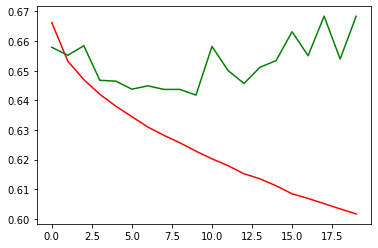

```python
model = Sequential()

# RNN
# 입력층 설정
model.add(GRU(32,input_shape=(2, 21)))

# 은닉층 추가
model.add(Dense(32, activation='relu'))
model.add(Dense(32, activation='relu'))
model.add(Dense(16, activation='relu'))
model.add(Dense(16, activation='relu'))

# 출력레이어
model.add(Dense(1, activation='sigmoid'))

# 설정
model.compile(optimizer='rmsprop', loss='binary_crossentropy', metrics='acc')

# Early Stopping
es = EarlyStopping(monitor='val_loss', mode='min', patience=10, verbose=1)

# Model CheckPoint
mc = ModelCheckpoint('clustering_gru_model2.cp', monitor='val_loss', mode='min', save_best_only=True)

# 학습
history = model.fit(train_x, train_y, epochs=30, batch_size=32, validation_split=0.2, callbacks=[es, mc])

plt.plot(history.history['loss'], c='r')
plt.plot(history.history['val_loss'], c='g')
```

```python
from tensorflow.keras.models import load_model
```

```python
# 저장된 최적의 모델 로드ㅁ
model = load_model('clustering_gru_model2.cp')
# 검증용 데이터로 loss/accuracy 재계산
model.evaluate(valid_x, valid_y) # loss, acc
```

```
[0.6426494717597961, 0.6235714554786682]
```

#### RNN-LSTM

은닉층의 수와 활성화 함수에 약간의 변화를 가하였다

```
...
(중략)
...
Epoch 20: early stopping
```

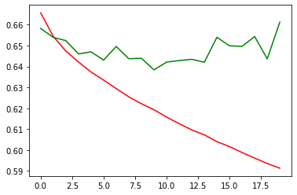

```python
model = Sequential()

# RNN
# 입력층 설정
model.add(LSTM(32,input_shape=(2, 21)))

# 은닉층 추가
model.add(Dense(32, activation='relu'))
model.add(Dense(32, activation='relu'))
model.add(Dense(32, activation='relu'))
model.add(Dense(16, activation='tanh'))
model.add(Dense(16, activation='tanh'))
model.add(Dense(16, activation='tanh'))

# 출력레이어
model.add(Dense(1, activation='sigmoid'))

# 설정
model.compile(optimizer='rmsprop', loss='binary_crossentropy', metrics='acc')

# Early Stopping
es = EarlyStopping(monitor='val_loss', mode='min', patience=10, verbose=1)

# Model CheckPoint
mc = ModelCheckpoint('clustering_lstm_model2.cp', monitor='val_loss', mode='min', save_best_only=True)

# 학습
history = model.fit(train_x, train_y, epochs=30, batch_size=32, validation_split=0.2, callbacks=[es, mc])

plt.plot(history.history['loss'], c='r')
plt.plot(history.history['val_loss'], c='g')
```

```python
# 저장된 최적의 모델 로드
model = load_model('clustering_lstm_model2.cp')
# 검증용 데이터로 loss/accuracy 재계산
model.evaluate(valid_x, valid_y) # loss, acc
```

```
[0.6425025463104248, 0.6254147291183472]
```

```python
# 실제 데이터와 예측결과 비교
pred = model(valid_x)
pred[5:10], valid_y[5:10] # 모델의 예측(확률값), 실제 게임 결과
```

```
(<tf.Tensor: shape=(5, 1), dtype=float32, numpy=
 array([[0.7188867 ],
        [0.5438688 ],
        [0.40957567],
        [0.18964532],
        [0.27441928]], dtype=float32)>,
 array([1, 1, 0, 0, 1]))
```

```python
# 모델이 70% 이상의 확률로 승 혹은 패를 예측한 경우
(pred>=0.7).numpy().sum(), (pred<=0.3).numpy().sum() # 승, 패로 각각 예측한 건수
```

```
(4426, 3451)
```

#### 모델 비교(loss/accuracy)

1. 첫번째 모델- GRU / early stopping 적용 / 은닉층 4개 / 활성화함수 - relu
- 0.643, 0.624
1. 두번째 모델- LSTM / early stopping 적용 / 은닉층 6개 / 활성화함수 - relu, tanh
- 0.643, 0.625

#### 모델 평가

1차 분석에 비하면 이번 모델의 정확도는 약 2.1%정도 향상되었다. 역시 모델 튜닝으로 개선의 여지는 있겠으나, 모델 자체의 오류가 존재한다고 판단되어 모델링을 중지하였다.

다만 모델이 예측결과에 얼마나 더 확신을 갖고 있는가에 대한 부분은 확실한 개선이 있었다. 이번 모델이 70%이상의 확률로 예측한 게임 수는 약 7900건으로 1차 모델에 비하면 강한 확신을 갖는 경우가 많았다고 볼 수 있다.

그러나 여전히 전체 게임수에 비하면 절반도 안되는 수치이며, 모델의 예측엔 신뢰도가 부족하다고 판단된다.

#### 피드백

가장 큰 문제점으로, 모델이 승패예측을 판단하는 과정을 분석 할 수 없다는 점이다. 이번 분석의 목표는 팀의 챔피언 구성의 어떤 요소가 승리에 직접적인 영향을 주는가에 대해 확인하는 것인데, 이에 대한 모델 해석을 전혀 진행 할 수가 없다.

하지만 1차 분석과 비교한다면 확실히 성능의 개선은 있었고, 이는 PCA를 통한 분석이 유효하다고 생각 할 수 있다. 이에 PCA 분석결과를 다른 알고리즘에 적용하기로 판단하였다.